# SR_hw13

Rachel Kaufman

2023-02-03

#### **13E1. Which of the following priors will produce more shrinkage in the estimates?**

The smaller prior, the more of a shrinkage we will see in our estimates! SO, the answer is Normal(0,1).

#### **13E2. Rewrite the following model as a multilevel model.**

$$\begin{aligned} \\
\ y_i &\sim Binomial(1,pi) \\
\ logit(pi) = \alpha(group[i]) +\alpha(x)_(i) \\
\ \alpha(group) &\sim Normal(\alpha(bar),\sigma) \\
\ \beta ∼ Normal(0,1) \\
\ \alpha(bar) ∼ Normal(0,10) \\
\ \alpha\sigma ∼ HalfCauchy(0,1) \\
\end{aligned}$$

#### **13E3. Rewrite the following model as a multilevel model.**

$$\begin{aligned}
y_i &\sim Normal(μ_i, σ) \\
\ \sigma &\sim Exponential(1) \\
\ \mu_i = \alpha[i] + \beta(x)_i \\
\ \beta &\sim Normal(0, 1) \\
\ \alpha_[i] &\sim Normal(\alpha(bar), \sigma) \\
\ \alpha(bar) &\sim Normal(0, 5) \\
\ \sigma &\sim exp(0,1) \\
\end{aligned}$$

#### **13E4. Write a mathematical model formula for a Poisson regression with varying intercepts.**

$$\begin{aligned}
\ y_i &\sim Poisson(\lambda_i) \\
\ logit(\lambda_i) = \alpha[i] + \beta(x_i) \\
\ \alpha[i] &\sim Normal(\alpha(bar), \sigma) \\
\ \beta &\sim Normal(0,1) \\
\ \alpha(bar) &\sim Normal(0,1) \\
\ \sigma_l2 &\sim Exp(0,1) \\
\end{aligned}$$

#### **13E5. Write a mathematical model formula for a Poisson regression with two different kinds of varying intercepts, a cross-classified model.**

$$\begin{aligned}
\ y_i &\sim Poisson(\lambda_i) \\
\ logit(\lambda_i) = a_l1 + a1[i] + a2[i] + beta(x_i) \\
\ \alpha_l1 &\sim Normal(0, 10) \\
\ \beta &\sim Normal(0,1) \\
\ \alpha[i] &\sim Normal(0, \sigma) \\
\ \alpha[i] &\sim Normal(0, \sigma2) \\
\ \sigma &\sim HalfCauchy(0,1) \\
\ \sigma2 &\sim HalfCauchy(0,1) \\
\end{aligned}$$

#### **13M1. Revisit the Reed frog survival data, data(reedfrogs), and add the predation and size treatment variables to the varying intercepts model. Consider models with either main effect alone, both main effects, as well as a model including both and their interaction. Instead of focusing on inferences about these two predictor variables, focus on the inferred variation across tanks. Explain why it changes as it does across models.**

```r
library(rethinking)
library(tidyverse)
library(dplyr)
data(reedfrogs)
d <- tibble(reedfrogs)
d <- d %>%
  mutate(tank = 1:nrow(d)) %>%
  mutate(big = if_else(size == "big", 1L, 0L)) %>%
  mutate(pred = if_else(pred == "no", 0L, 1L)) %>%
  mutate(N = density) %>%
  mutate(S = surv) %>%
  select(S, N, tank, big, pred)

# make model with one main effect alone
set.seed(1229)
m13.1a <- ulam(
  alist(
    S ~ dbinom(N, p),
     logit(p) <- a[tank] + b * big,
        b ~ dnorm(0, 0.5),
   a[tank] ~ dnorm(a_bar, sigma),
    a_bar ~ dnorm(0, 1.5),
    sigma ~ dexp(1)), data = d,
    chains = 4, log_lik = TRUE)
```

[output not shown]

```
## Chain 4 Informational Message: The current Metropolis proposal is about to be rejected because of the following issue:
```

[output not shown]

```
## Chain 4 If this warning occurs sporadically, such as for highly constrained variable types like covariance matrices, then the sampler is fine,
```

```
## Chain 4 but if this warning occurs often then your model may be either severely ill-conditioned or misspecified.
```

```
## Chain 4
```

```
## Chain 4 Iteration: 400 / 1000 [ 40%]  (Warmup)
## Chain 4 Iteration: 500 / 1000 [ 50%]  (Warmup)
## Chain 4 Iteration: 501 / 1000 [ 50%]  (Sampling)
## Chain 4 Iteration: 600 / 1000 [ 60%]  (Sampling)
## Chain 4 Iteration: 700 / 1000 [ 70%]  (Sampling)
## Chain 4 Iteration: 800 / 1000 [ 80%]  (Sampling)
## Chain 4 Iteration: 900 / 1000 [ 90%]  (Sampling)
## Chain 4 Iteration: 1000 / 1000 [100%]  (Sampling)
## Chain 4 finished in 0.2 seconds.
##
## All 4 chains finished successfully.
## Mean chain execution time: 0.2 seconds.
## Total execution time: 1.4 seconds.
```

```r
# make model with both main effect alone

m13.1b <- ulam(
  alist(
    S ~ dbinom(N,p),
      logit(p) <- a[tank] + b * big + x * pred,
      b ~ dnorm(0, 0.5),
      x ~ dnorm(0, 0.5),
      a[tank] ~ dnorm(a_bar, sigma),
      a_bar ~ dnorm(0, 1.5),
      sigma ~ dexp(1)), data = d, chains = 4, log_lik = TRUE)
```

```
## Running MCMC with 4 sequential chains, with 1 thread(s) per chain...
##
## Chain 1 Iteration:   1 / 1000 [  0%]  (Warmup)
## Chain 1 Iteration: 100 / 1000 [ 10%]  (Warmup)
## Chain 1 Iteration: 200 / 1000 [ 20%]  (Warmup)
## Chain 1 Iteration: 300 / 1000 [ 30%]  (Warmup)
```

```
## Chain 1 Informational Message: The current Metropolis proposal is about to be rejected because of the following issue:
```

```
## Chain 1 Exception: normal_lpdf: Scale parameter is 0, but must be positive! (in '/var/folders/7l/91czy21j3yj6mwd67njrmp1w0000gn/T/RtmppRgiGo/model-600c766730ac.stan', line 19, column 4 to column 32)
```

```
## Chain 1 If this warning occurs sporadically, such as for highly constrained variable types like covariance matrices, then the sampler is fine,
```

```
## Chain 1 but if this warning occurs often then your model may be either severely ill-conditioned or misspecified.
```

```
## Chain 1
```

```
## Chain 1 Iteration: 400 / 1000 [ 40%]  (Warmup)
## Chain 1 Iteration: 500 / 1000 [ 50%]  (Warmup)
## Chain 1 Iteration: 501 / 1000 [ 50%]  (Sampling)
## Chain 1 Iteration: 600 / 1000 [ 60%]  (Sampling)
## Chain 1 Iteration: 700 / 1000 [ 70%]  (Sampling)
## Chain 1 Iteration: 800 / 1000 [ 80%]  (Sampling)
## Chain 1 Iteration: 900 / 1000 [ 90%]  (Sampling)
## Chain 1 Iteration: 1000 / 1000 [100%]  (Sampling)
## Chain 1 finished in 0.3 seconds.
## Chain 2 Iteration:   1 / 1000 [  0%]  (Warmup)
## Chain 2 Iteration: 100 / 1000 [ 10%]  (Warmup)
## Chain 2 Iteration: 200 / 1000 [ 20%]  (Warmup)
## Chain 2 Iteration: 300 / 1000 [ 30%]  (Warmup)
```

```
## Chain 2 Informational Message: The current Metropolis proposal is about to be rejected because of the following issue:
```

```
## Chain 2 Exception: normal_lpdf: Scale parameter is 0, but must be positive! (in '/var/folders/7l/91czy21j3yj6mwd67njrmp1w0000gn/T/RtmppRgiGo/model-600c766730ac.stan', line 19, column 4 to column 32)
```

```
## Chain 2 If this warning occurs sporadically, such as for highly constrained variable types like covariance matrices, then the sampler is fine,
```

```
## Chain 2 but if this warning occurs often then your model may be either severely ill-conditioned or misspecified.
```

```
## Chain 2
```

[output not shown]

```r
# interaction model

m13.1c  <- ulam(
  alist(
      S ~ dbinom(N,p),
      logit(p) <- a[tank] + b * big + x * pred + z * big * pred,
        b ~ dnorm(0, 0.5),
        x ~ dnorm(0,0.5),
        z ~ dnorm(0,0.5),
        a[tank] ~ dnorm(a_bar, sigma),
        a_bar ~ dnorm(0, 1.5),
        sigma ~ dexp(1)),
  data = d, chains = 4, log_lik = TRUE)
```

```
## Running MCMC with 4 sequential chains, with 1 thread(s) per chain...
##
## Chain 1 Iteration:   1 / 1000 [  0%]  (Warmup)
## Chain 1 Iteration: 100 / 1000 [ 10%]  (Warmup)
## Chain 1 Iteration: 200 / 1000 [ 20%]  (Warmup)
```

```
## Chain 1 Informational Message: The current Metropolis proposal is about to be rejected because of the following issue:
```

```
## Chain 1 Exception: normal_lpdf: Scale parameter is 0, but must be positive! (in '/var/folders/7l/91czy21j3yj6mwd67njrmp1w0000gn/T/RtmppRgiGo/model-600c49bbfa8e.stan', line 20, column 4 to column 32)
```

```
## Chain 1 If this warning occurs sporadically, such as for highly constrained variable types like covariance matrices, then the sampler is fine,
```

```
## Chain 1 but if this warning occurs often then your model may be either severely ill-conditioned or misspecified.
```

```
## Chain 1
```

[output not shown]

```
## Chain 4 Informational Message: The current Metropolis proposal is about to be rejected because of the following issue:
```

```
## Chain 4 Exception: normal_lpdf: Scale parameter is 0, but must be positive! (in '/var/folders/7l/91czy21j3yj6mwd67njrmp1w0000gn/T/RtmppRgiGo/model-600c49bbfa8e.stan', line 20, column 4 to column 32)
```

```
## Chain 4 If this warning occurs sporadically, such as for highly constrained variable types like covariance matrices, then the sampler is fine,
```

```
## Chain 4 but if this warning occurs often then your model may be either severely ill-conditioned or misspecified.
```

```
## Chain 4
```

```
## Chain 4 Iteration: 300 / 1000 [ 30%]  (Warmup)
## Chain 4 Iteration: 400 / 1000 [ 40%]  (Warmup)
## Chain 4 Iteration: 500 / 1000 [ 50%]  (Warmup)
## Chain 4 Iteration: 501 / 1000 [ 50%]  (Sampling)
## Chain 4 Iteration: 600 / 1000 [ 60%]  (Sampling)
## Chain 4 Iteration: 700 / 1000 [ 70%]  (Sampling)
## Chain 4 Iteration: 800 / 1000 [ 80%]  (Sampling)
## Chain 4 Iteration: 900 / 1000 [ 90%]  (Sampling)
## Chain 4 Iteration: 1000 / 1000 [100%]  (Sampling)
## Chain 4 finished in 0.4 seconds.
##
## All 4 chains finished successfully.
## Mean chain execution time: 0.3 seconds.
## Total execution time: 1.7 seconds.
```

#### **13M2. Compare the models you it just above, using WAIC. Can you reconcile the differences in WAIC with the posterior distributions of the models?**

```r
precis(m13.1a)
```

```
## 48 vector or matrix parameters hidden. Use depth=2 to show them.
```

```
##             mean        sd       5.5%     94.5%     n_eff    Rhat4
## b     -0.2248863 0.3515562 -0.7874162 0.3423514  264.4285 1.006137
## a_bar  1.4476570 0.3077827  0.9742555 1.9512148  505.3981 1.004915
## sigma  1.6081812 0.2132029  1.2998512 1.9787313 1259.4535 1.000297
```

```r
precis(m13.1b)
```

```
## 48 vector or matrix parameters hidden. Use depth=2 to show them.
```

```
##             mean        sd       5.5%      94.5%    n_eff    Rhat4
## b     -0.3217594 0.2804280 -0.7656025  0.1393159 549.4784 1.005221
## x     -1.8657490 0.2993950 -2.3148304 -1.3786908 320.9655 1.013069
## a_bar  2.3670868 0.2662533  1.9425964  2.7843418 311.5691 1.014907
## sigma  0.8708559 0.1708299  0.6227317  1.1668499 531.3408 1.003544
```

```r
precis(m13.1c)
```

```
## 48 vector or matrix parameters hidden. Use depth=2 to show them.
```

```
##              mean        sd       5.5%      94.5%     n_eff    Rhat4
## b      0.05600709 0.2819346 -0.4003048  0.5054501  646.0701 1.002355
## x     -1.58332198 0.2958667 -2.0574384 -1.0992143  341.7568 1.005369
## z     -0.92315629 0.3426601 -1.4521950 -0.3544199 1210.5444 1.000035
## a_bar  2.27226048 0.2424661  1.8821412  2.6497030  299.6266 1.002544
## sigma  0.78493580 0.1605476  0.5606256  1.0557361  434.6036 1.007766
```

```r
compare(m13.1a, m13.1b, m13.1c)
```

```
##            WAIC       SE    dWAIC      dSE    pWAIC    weight
## m13.1c 197.9203 8.572533 0.000000       NA 18.48047 0.5701069
## m13.1a 199.6892 7.120540 1.768909 5.548051 20.61657 0.2354196
## m13.1b 200.0713 8.067640 2.151055 2.696926 19.72178 0.1944735
```

#### **13M3. Re-estimate the basic Reed frog varying intercept model, but now using a Cauchy distribution in place of the Gaussian distribution for the varying intercepts. That is, it this model:**

```r
m13m3.base <- ulam(
  alist(
    S ~ dbinom(N, p),
    logit(p) <- a_tank[tank],
    a_tank[tank] ~ dnorm(a, sigma),
    a ~ dnorm(0, 1),
    sigma ~ dexp(1)),
  data = d,
  iter = 2000, chains = 2, cores = 2)
```

[output not shown]

```r
m13m3.base.cauchy <- ulam(
  alist(
    S ~ dbinom(N, p),
    logit(p) <- a_tank[tank],
    a_tank[tank] ~ dcauchy(a, sigma),
    a ~ dnorm(0, 1),
    sigma ~ dcauchy(0,1)),
  data =  d,
  iter = 2000, chains = 2, cores = 2)
```

[output not shown]

```r
precis(m13m3.base)
```

```
## 48 vector or matrix parameters hidden. Use depth=2 to show them.
```

```
##           mean        sd     5.5%    94.5%    n_eff     Rhat4
## a     1.294935 0.2400065 0.926704 1.690193 2512.480 0.9993682
## sigma 1.614627 0.2053554 1.309891 1.961229 1366.377 1.0014021
```

```r
precis(m13m3.base.cauchy, depth = 2)
```

```
##                   mean         sd        5.5%        94.5%      n_eff     Rhat4
## a_tank[1]   2.03582694  0.8934347  0.90141317  3.656854450 1214.57958 1.0017294
## a_tank[2]   6.77780265 11.4468341  1.38434485 19.992065500   75.96144 1.0281305
## a_tank[3]   1.10848008  0.5916285  0.18710435  2.046874100 3139.25863 1.0000294
## a_tank[4]   6.04452382  9.3866618  1.41804600 15.825252000  208.17559 1.0122576
## a_tank[5]   2.00155827  0.8360640  0.85417983  3.441950600 1649.02748 0.9997063
## a_tank[6]   2.00810617  0.8752999  0.89459868  3.480044800 1388.80761 0.9991330
## a_tank[7]   5.63879635  9.5315823  1.48761480 14.052395000  209.67347 1.0062204
## a_tank[8]   1.97091014  0.8165915  0.88775730  3.377325750 1878.99213 1.0005424
## a_tank[9]  -0.06840567  0.7086910 -1.27150440  1.038041350 2290.14666 0.9993587
## a_tank[10]  2.04043760  0.8474360  0.90076000  3.506393550 1142.10318 0.9993811
## a_tank[11]  1.08888046  0.6268495  0.12546447  2.054189100 2437.99981 0.9994708
## a_tank[12]  0.73879768  0.6195864 -0.25752345  1.684820500 2962.68469 1.0018367
## a_tank[13]  1.09566511  0.6296272  0.10161611  2.105795000 2120.97382 0.9995274
## a_tank[14]  0.35585048  0.6426794 -0.69657292  1.360203200 2844.05432 0.9997387
## a_tank[15]  2.05369676  0.9219214  0.83532595  3.662603350 1356.40209 1.0001405
## a_tank[16]  2.02119113  0.8550261  0.83389938  3.586233750 1629.05395 1.0005071
## a_tank[17]  2.87997602  0.9734680  1.67328525  4.583279250 1040.34681 1.0035341
## a_tank[18]  2.26777218  0.6755294  1.29839450  3.452296500 2154.36044 0.9992995
## a_tank[19]  1.89209142  0.5125860  1.14137075  2.772590450 2298.60969 0.9997741
## a_tank[20] 14.52323209 26.5952247  2.47486585 56.448790500   64.59996 1.0389809
## a_tank[21]  2.25670991  0.6620261  1.34871890  3.401415900 1745.36879 1.0000295
## a_tank[22]  2.27045103  0.6693853  1.33980385  3.458156700 1743.82876 1.0002742
## a_tank[23]  2.27047567  0.6506655  1.35634320  3.366412750 2140.31901 0.9992513
## a_tank[24]  1.64890727  0.4836131  0.91474797  2.477613700 2757.23838 1.0005435
## a_tank[25] -1.05357110  0.4736378 -1.84843215 -0.347762885 2443.58679 0.9999514
## a_tank[26]  0.22212759  0.4072036 -0.43235888  0.853061300 2514.73658 1.0000700
## a_tank[27] -1.57043941  0.5618176 -2.52389600 -0.744138955 2491.90864 0.9996930
## a_tank[28] -0.45285655  0.4400256 -1.16914015  0.224767935 2790.46216 1.0000930
## a_tank[29]  0.22792609  0.4176859 -0.42715738  0.899558205 2621.72319 0.9994331
## a_tank[30]  1.44395969  0.4400424  0.76580792  2.176231850 2466.85687 0.9998161
## a_tank[31] -0.65074427  0.4439588 -1.37632990  0.052682827 1944.01246 0.9997578
## a_tank[32] -0.28132758  0.4267111 -0.94667173  0.397133100 2170.50525 0.9993500
## a_tank[33]  3.23830430  0.9509758  2.02356060  4.930013650 1535.99268 0.9994619
## a_tank[34]  2.61611019  0.6794992  1.65677725  3.802509650 1540.76556 0.9998012
## a_tank[35]  2.61744024  0.6884724  1.66375670  3.855722950 1673.22777 1.0002876
## a_tank[36]  1.95333214  0.4817242  1.24257740  2.781268850 2117.71033 0.9993545
## a_tank[37]  1.98426380  0.4932600  1.29432830  2.825455400 1888.41956 1.0011142
## a_tank[38] 11.07463220 22.9887535  2.74369735 28.472003000  255.82385 1.0098041
## a_tank[39]  2.58212114  0.6525136  1.67505825  3.730266500 1898.67377 1.0005675
## a_tank[40]  2.24791356  0.5675473  1.44367150  3.245699700 1723.23774 0.9993521
## a_tank[41] -2.01449190  0.5395243 -2.96000265 -1.233692050 2326.61478 0.9999267
## a_tank[42] -0.55658639  0.3494077 -1.12165370 -0.004387768 2866.68452 0.9995337
## a_tank[43] -0.43384753  0.3629614 -1.01451615  0.146183695 2892.95338 0.9998210
## a_tank[44] -0.30605798  0.3634022 -0.88427202  0.276215015 2996.21315 0.9990651
## a_tank[45]  0.63914107  0.3550761  0.08402816  1.212281750 2285.52243 0.9992005
## a_tank[46] -0.56429058  0.3454317 -1.10476880 -0.005052938 2973.67113 1.0004731
## a_tank[47]  1.95935849  0.4695424  1.25910580  2.777112850 2364.03200 0.9996495
## a_tank[48]  0.06697732  0.3557778 -0.48877739  0.621189990 2591.84569 0.9998189
## a           1.40292618  0.2858380  0.94259195  1.841067500 1349.99718 0.9999556
## sigma       1.02501119  0.2237292  0.70011663  1.405872100 1266.51876 0.9999753
```

#### **13M4. Now use a Student-t distribution with ν = 2 for the intercepts:**

**Can you explain the differences?**

```r
m13m4.student <- ulam(
  alist(
    S ~ dbinom(N, p),
    logit(p) <- a_tank[tank],
    a_tank[tank] ~ dstudent(2, a, sigma),
    a ~ dnorm(0, 1),
    sigma ~ dcauchy(0,1)),
  data = d,
  iter = 2000, chains = 2, cores = 2)
```

```
## Running MCMC with 2 parallel chains, with 1 thread(s) per chain...
##
## Chain 1 Iteration:    1 / 2000 [  0%]  (Warmup)
## Chain 1 Iteration:  100 / 2000 [  5%]  (Warmup)
## Chain 1 Iteration:  200 / 2000 [ 10%]  (Warmup)
## Chain 1 Iteration:  300 / 2000 [ 15%]  (Warmup)
## Chain 1 Iteration:  400 / 2000 [ 20%]  (Warmup)
```

```
## Chain 1 Informational Message: The current Metropolis proposal is about to be rejected because of the following issue:
```

[output not shown]

```
## Chain 1 If this warning occurs sporadically, such as for highly constrained variable types like covariance matrices, then the sampler is fine,
```

```
## Chain 1 but if this warning occurs often then your model may be either severely ill-conditioned or misspecified.
```

```
## Chain 1
```

[output not shown]

```r
precis(m13m4.student, depth = 2)
```

```
##                   mean        sd        5.5%        94.5%     n_eff     Rhat4
## a_tank[1]   2.04353545 0.8393405  0.83513826  3.450456800 2581.4795 0.9995003
## a_tank[2]   3.75966817 2.5782113  1.40564520  8.025848150  544.2305 1.0061654
## a_tank[3]   1.04780875 0.6373553  0.04914443  2.066900150 3003.4026 0.9994834
## a_tank[4]   3.90060568 2.9170156  1.44162065  8.368384000  455.0933 1.0016319
## a_tank[5]   2.08084883 0.8922072  0.84540936  3.624552200 1579.2788 1.0004719
## a_tank[6]   2.07173529 0.8649852  0.87839777  3.562797900 2019.8132 0.9997711
## a_tank[7]   3.74707500 2.4076072  1.49063380  8.240361750  507.8408 1.0010513
## a_tank[8]   2.01563135 0.7993469  0.86996379  3.443255300 2428.3391 1.0000417
## a_tank[9]  -0.09516881 0.6354279 -1.14008410  0.892371930 3332.1658 0.9996460
## a_tank[10]  2.03527689 0.8355999  0.85454145  3.455891850 2549.4798 0.9996340
## a_tank[11]  1.03939453 0.6451211  0.01509897  2.101161450 3213.0877 0.9998179
## a_tank[12]  0.67636625 0.6373258 -0.32941943  1.688012850 3827.1807 0.9993711
## a_tank[13]  1.04708732 0.6285139  0.07751103  2.107967950 2759.6886 0.9998942
## a_tank[14]  0.28774918 0.6152883 -0.69861493  1.246253300 3166.6255 0.9992441
## a_tank[15]  2.01845548 0.8328384  0.86776831  3.377469150 1974.8737 0.9993147
## a_tank[16]  2.05078350 0.8741855  0.82197965  3.549177850 2214.3725 0.9993655
## a_tank[17]  2.89604755 0.9030334  1.68207605  4.491486000 1973.4398 1.0006622
## a_tank[18]  2.34806254 0.6829081  1.36482990  3.521849800 2221.3738 0.9991325
## a_tank[19]  1.95450893 0.5514821  1.13880290  2.859317800 3444.4088 0.9992154
## a_tank[20]  5.24454187 4.5129599  2.31733115  9.856855750  151.2182 1.0283366
## a_tank[21]  2.30286501 0.6516138  1.35057270  3.417003750 2120.2596 1.0014667
## a_tank[22]  2.29496908 0.6266924  1.40384675  3.350463800 2625.7574 0.9992713
## a_tank[23]  2.30433681 0.6966425  1.37466175  3.423361450 2001.5803 0.9992469
## a_tank[24]  1.65723492 0.4812767  0.91864044  2.471474850 2796.7772 1.0000074
## a_tank[25] -1.02810190 0.4851221 -1.81342490 -0.267314025 3616.1849 0.9991789
## a_tank[26]  0.20715058 0.3862571 -0.40091235  0.840635030 2770.6442 0.9998734
## a_tank[27] -1.53368849 0.5470308 -2.44037490 -0.728821840 2866.5357 1.0001869
## a_tank[28] -0.45155496 0.4350870 -1.16241470  0.223701050 4220.2768 0.9992906
## a_tank[29]  0.20321852 0.4040557 -0.43102244  0.844622475 4450.1841 1.0001477
## a_tank[30]  1.43903644 0.4625875  0.74972337  2.210034450 3695.9653 0.9991809
## a_tank[31] -0.63236087 0.4205610 -1.28283295 -0.005543343 3017.4175 0.9994269
## a_tank[32] -0.27813157 0.3899635 -0.90397966  0.327439410 3533.3171 0.9990938
## a_tank[33]  3.19921281 0.8259146  2.03980440  4.615798550 2272.2080 0.9991355
## a_tank[34]  2.62807306 0.6430622  1.71950665  3.760927000 2542.8622 0.9995590
## a_tank[35]  2.64410739 0.6869556  1.66715925  3.772118150 2146.8585 1.0001141
## a_tank[36]  2.00402856 0.5125289  1.25347965  2.876252850 3081.1848 0.9994618
## a_tank[37]  2.01223097 0.4980848  1.28504760  2.836400600 2549.2331 1.0004347
## a_tank[38]  5.77194911 4.4318134  2.63388340 11.995283500  420.3060 1.0073484
## a_tank[39]  2.64362140 0.6894654  1.65777730  3.802553450 2494.2324 0.9993716
## a_tank[40]  2.26701000 0.5732824  1.42982240  3.236302150 2611.7679 0.9994072
## a_tank[41] -1.96763468 0.5445611 -2.86215685 -1.162520350 3147.4264 1.0004186
## a_tank[42] -0.54984527 0.3617012 -1.17051960  0.016900399 2875.8561 0.9997463
## a_tank[43] -0.44223537 0.3369544 -0.98795718  0.083582666 3434.8569 0.9991896
## a_tank[44] -0.32047835 0.3550400 -0.88165918  0.219216820 3656.6809 0.9990930
## a_tank[45]  0.61321789 0.3600990  0.05141129  1.210290650 3145.2322 0.9998346
## a_tank[46] -0.55755922 0.3654993 -1.14049980  0.019962211 4043.1444 0.9993500
## a_tank[47]  2.00452115 0.4917898  1.24920955  2.874526300 2907.7791 1.0000713
## a_tank[48]  0.03828356 0.3434153 -0.52696031  0.598585615 3393.9652 0.9990629
## a           1.34805444 0.2695602  0.91286507  1.774497150 2919.0052 0.9995693
## sigma       1.24857191 0.2214557  0.92618413  1.628445650 2074.5981 0.9996180
```

Compared to the exponential sigma prior, a Cauchy prior for the standard deviation of the residuals is also a heavy-tailed distribution and allows for a wider range of possible values for the standard deviation. The difference between the two is that the exponential prior is defined over positive real numbers only, while the Cauchy prior is defined over the entire real line. This means that the Cauchy prior is less restrictive in terms of the range of possible values for the standard deviation, but also has a heavier tail, which makes it more sensitive to outliers.

In comparison to the original model, the Student-t distribution with ν=2 and the Cauchy prior allow for a wider range of possible values for the intercept and standard deviation, respectively, which makes the posterior less sensitive to the choice of prior. However, it also means that the posterior is more influenced by the data and less influenced by prior beliefs.

#### **13M6. Sometimes the prior and the data (through the likelihood) are in conflict, because they concentrate around different regions of parameter space. What happens in these cases depends a lot upon the shape of the tails of the distributions.202 Likewise, the tails of distributions strongly influence can outliers are shrunk or not towards the mean. I want you to consider four different models to it to one observation at y = 0. he models differ only in the distributions assigned to the likelihood and prior. Here are the four models:**

```r
data(chimpanzees)
dchimp <- chimpanzees %>%
  drop_na()

m13m6.1 <- ulam(
  alist(
    pulled_left ~ dnorm(mu, 1),
    mu~dnorm(10,1)),
  data = dchimp,
 iter = 2000, chains = 1, cores = 1)
```

[output not shown]

[output not shown]

```r
m13m6.2 <- ulam(
  alist(
    pulled_left ~ dstudent(2, mu, 1),
    mu~dnorm(10,1)),
  data = dchimp,
  iter = 2000, chains = 1, cores = 1)
```

[output not shown]

[output not shown]

```r
m13m6.3 <- ulam(
  alist(
    pulled_left ~ dnorm(mu, 1),
    mu~dstudent(2,10,1)),
  data = dchimp,
  iter = 2000, chains = 1, cores = 1)
```

[output not shown]

[output not shown]

```r
m13m6.4 <- ulam(
  alist(
    pulled_left ~ dstudent(2,mu, 1),
    mu~dstudent(2,10,1)),
  data = dchimp,
  iter = 2000, chains = 1, cores = 1)
```

[output not shown]

[output not shown]

```r
precis(m13m6.1)
```

```
##            result
## mean    0.5932429
## sd      0.0652437
## 5.5%    0.4892365
## 94.5%   0.6983838
## n_eff 274.7463152
## Rhat    0.9993612
```

```r
precis(m13m6.2)
```

```
##             result
## mean    0.60527049
## sd      0.06006861
## 5.5%    0.50547739
## 94.5%   0.69764534
## n_eff 421.33711779
## Rhat    0.99989238
```

```r
precis(m13m6.3)
```

```
##             result
## mean    0.55142355
## sd      0.06562254
## 5.5%    0.44781231
## 94.5%   0.65581108
## n_eff 421.97247796
## Rhat    0.99907517
```

```r
precis(m13m6.4)
```

```
##             result
## mean    0.56908038
## sd      0.06172321
## 5.5%    0.46399893
## 94.5%   0.66682623
## n_eff 296.00991118
## Rhat    1.00071159
```

#### **14E2. think up a context in which varying intercepts will be positively correlated with varying slopes. Provide a mechanistic explanation for the correlation.**

Suppose there is a clothing store with varying slopes predicting sales, and that they will have positive correlations. This store is in different regions with varying climates, as a result, it only makes sense that the sales of winter clothing in a region with a cold climate is much higher than in a region with a warm climate. The intercept for the cold climate region will be higher than the intercept for the warm climate region, and the slope for the cold climate region will be steeper than the slope for the warm climate region. This relationship between the intercepts and slopes reflects the influence of climate on the sales of winter clothing.

#### **14E3. When is it possible for a varying slopes model to have fewer effective parameters (as estimated by WAIC or PSIS) than the corresponding model with fixed (unpooled) slopes? Explain.**

Varying slopes model CAN have fewer effective parameters (as estimated by WAIC or PSIS) than the corresponding model with fixed (unpooled) slopes when the data is better described by the model with varying slopes, i.e., the varying slopes model is a better fit to the data. The purpose of WAIC and PSIS is to measure the amount of information lost by using a particular model to describe the data. If a model with varying slopes is a better fit to the data, it will result in less information loss and therefore have a lower WAIC or PSIS value compared to a model with fixed slopes (even with more parameters heeh). This suggests that the model with varying slopes has a more parsimonious structure… ooo lala, thus provides a better explanation of the data with fewer parameters.

#### **14M1. Repeat the café robot simulation from the beginning of the chapter. his time, set rho to zero, so that there is no correlation between intercepts and slopes. How does the posterior distribution of the correlation reflect this change in the underlying simulation?**

```r
set.seed(1676)
a <- 3.5 # average morning wait time
b <- (-1) # average difference afternoon wait time
sigma_a <- 1 # std dev in intercepts
sigma_b <- 0.5 # std dev in slopes
rho <- 0 # correlation between intercepts and slopes

Mu <- c(a, b)
cov_ab <- sigma_a * sigma_b * rho
Sigma <- matrix(c(sigma_a^2, cov_ab, cov_ab, sigma_b^2), ncol = 2)

# simulate observations
N_cafes <- 20
set.seed(6)
vary_effects <- rnorm(N_cafes, Mu, Sigma)
a_cafe <- vary_effects[ 1]
b_cafe <- vary_effects[ 2]

N_visits <- 10
afternoon <- rep(0:1, N_visits * N_cafes / 2)
cafe_id <- rep(1:N_cafes, each = N_visits)
mu <- a_cafe[cafe_id] + b_cafe[cafe_id]*afternoon
sigma <- 0.5 # std dev within cafes
wait <- rnorm(N_visits * N_cafes, mu, sigma)
# package into  data frame
d3 <- data.frame(cafe = cafe_id, afternoon = afternoon, wait = wait)

m14.M1 <- ulam(
  alist(
    wait ~ normal(mu, sigma),
    mu <- a_cafe[cafe] + b_cafe[cafe] * afternoon,
    c(a_cafe, b_cafe)[cafe] ~ multi_normal(c(a, b), Rho, sigma_cafe),
    a ~ normal(5, 2),
    b ~ normal(-1, 0.5),
    sigma_cafe ~ exponential(1),
    sigma ~ exponential(1),
    Rho ~ lkj_corr(2)),
  data = d3, chains = 4, cores = 4)
```

```
## Found 190 NA values in wait and attempting imputation.
```

```
## Running MCMC with 4 parallel chains, with 1 thread(s) per chain...
##
## Chain 1 Iteration:   1 / 1000 [  0%]  (Warmup)
```

```
## Chain 1 Informational Message: The current Metropolis proposal is about to be rejected because of the following issue:
```

[output not shown]

```
## Chain 1 If this warning occurs sporadically, such as for highly constrained variable types like covariance matrices, then the sampler is fine,
```

```
## Chain 1 but if this warning occurs often then your model may be either severely ill-conditioned or misspecified.
```

```
## Chain 1
```

```
## Chain 2 Iteration:   1 / 1000 [  0%]  (Warmup)
```

```
## Chain 2 Informational Message: The current Metropolis proposal is about to be rejected because of the following issue:
```

```
## Chain 2 Exception: lkj_corr_lpdf: Correlation matrix is not positive definite. (in '/var/folders/7l/91czy21j3yj6mwd67njrmp1w0000gn/T/RtmppRgiGo/model-600c4ef831d2.stan', line 33, column 4 to column 24)
```

```
## Chain 2 If this warning occurs sporadically, such as for highly constrained variable types like covariance matrices, then the sampler is fine,
```

```
## Chain 2 but if this warning occurs often then your model may be either severely ill-conditioned or misspecified.
```

```
## Chain 2
```

```
## Chain 2 Informational Message: The current Metropolis proposal is about to be rejected because of the following issue:
```

[output not shown]

```
## Chain 2 If this warning occurs sporadically, such as for highly constrained variable types like covariance matrices, then the sampler is fine,
```

```
## Chain 2 but if this warning occurs often then your model may be either severely ill-conditioned or misspecified.
```

```
## Chain 2
```

```
## Chain 2 Informational Message: The current Metropolis proposal is about to be rejected because of the following issue:
```

[output not shown]

```
## Chain 2 If this warning occurs sporadically, such as for highly constrained variable types like covariance matrices, then the sampler is fine,
```

```
## Chain 2 but if this warning occurs often then your model may be either severely ill-conditioned or misspecified.
```

```
## Chain 2
```

```
## Chain 2 Informational Message: The current Metropolis proposal is about to be rejected because of the following issue:
```

[output not shown]

```
## Chain 2 If this warning occurs sporadically, such as for highly constrained variable types like covariance matrices, then the sampler is fine,
```

```
## Chain 2 but if this warning occurs often then your model may be either severely ill-conditioned or misspecified.
```

```
## Chain 2
```

```
## Chain 2 Informational Message: The current Metropolis proposal is about to be rejected because of the following issue:
```

[output not shown]

```
## Chain 2 If this warning occurs sporadically, such as for highly constrained variable types like covariance matrices, then the sampler is fine,
```

```
## Chain 2 but if this warning occurs often then your model may be either severely ill-conditioned or misspecified.
```

```
## Chain 2
```

```
## Chain 2 Informational Message: The current Metropolis proposal is about to be rejected because of the following issue:
```

[output not shown]

```
## Chain 2 If this warning occurs sporadically, such as for highly constrained variable types like covariance matrices, then the sampler is fine,
```

```
## Chain 2 but if this warning occurs often then your model may be either severely ill-conditioned or misspecified.
```

```
## Chain 2
```

```
## Chain 2 Informational Message: The current Metropolis proposal is about to be rejected because of the following issue:
```

[output not shown]

```
## Chain 2 If this warning occurs sporadically, such as for highly constrained variable types like covariance matrices, then the sampler is fine,
```

```
## Chain 2 but if this warning occurs often then your model may be either severely ill-conditioned or misspecified.
```

```
## Chain 2
```

```
## Chain 3 Iteration:   1 / 1000 [  0%]  (Warmup)
```

```
## Chain 3 Informational Message: The current Metropolis proposal is about to be rejected because of the following issue:
```

```
## Chain 3 Exception: lkj_corr_lpdf: Correlation matrix is not positive definite. (in '/var/folders/7l/91czy21j3yj6mwd67njrmp1w0000gn/T/RtmppRgiGo/model-600c4ef831d2.stan', line 33, column 4 to column 24)
```

```
## Chain 3 If this warning occurs sporadically, such as for highly constrained variable types like covariance matrices, then the sampler is fine,
```

```
## Chain 3 but if this warning occurs often then your model may be either severely ill-conditioned or misspecified.
```

```
## Chain 3
```

```
## Chain 4 Iteration:   1 / 1000 [  0%]  (Warmup)
```

```
## Chain 4 Informational Message: The current Metropolis proposal is about to be rejected because of the following issue:
```

```
## Chain 4 Exception: lkj_corr_lpdf: Correlation matrix is not positive definite. (in '/var/folders/7l/91czy21j3yj6mwd67njrmp1w0000gn/T/RtmppRgiGo/model-600c4ef831d2.stan', line 33, column 4 to column 24)
```

```
## Chain 4 If this warning occurs sporadically, such as for highly constrained variable types like covariance matrices, then the sampler is fine,
```

```
## Chain 4 but if this warning occurs often then your model may be either severely ill-conditioned or misspecified.
```

```
## Chain 4
```

```
## Chain 4 Informational Message: The current Metropolis proposal is about to be rejected because of the following issue:
```

[output not shown]

```
## Chain 4 If this warning occurs sporadically, such as for highly constrained variable types like covariance matrices, then the sampler is fine,
```

```
## Chain 4 but if this warning occurs often then your model may be either severely ill-conditioned or misspecified.
```

```
## Chain 4
```

```
## Chain 4 Informational Message: The current Metropolis proposal is about to be rejected because of the following issue:
```

[output not shown]

```
## Chain 4 If this warning occurs sporadically, such as for highly constrained variable types like covariance matrices, then the sampler is fine,
```

```
## Chain 4 but if this warning occurs often then your model may be either severely ill-conditioned or misspecified.
```

```
## Chain 4
```

```
## Chain 4 Informational Message: The current Metropolis proposal is about to be rejected because of the following issue:
```

[output not shown]

```
## Chain 4 If this warning occurs sporadically, such as for highly constrained variable types like covariance matrices, then the sampler is fine,
```

```
## Chain 4 but if this warning occurs often then your model may be either severely ill-conditioned or misspecified.
```

```
## Chain 4
```

```
## Chain 4 Informational Message: The current Metropolis proposal is about to be rejected because of the following issue:
```

[output not shown]

```
## Chain 4 If this warning occurs sporadically, such as for highly constrained variable types like covariance matrices, then the sampler is fine,
```

```
## Chain 4 but if this warning occurs often then your model may be either severely ill-conditioned or misspecified.
```

```
## Chain 4
```

[output not shown]

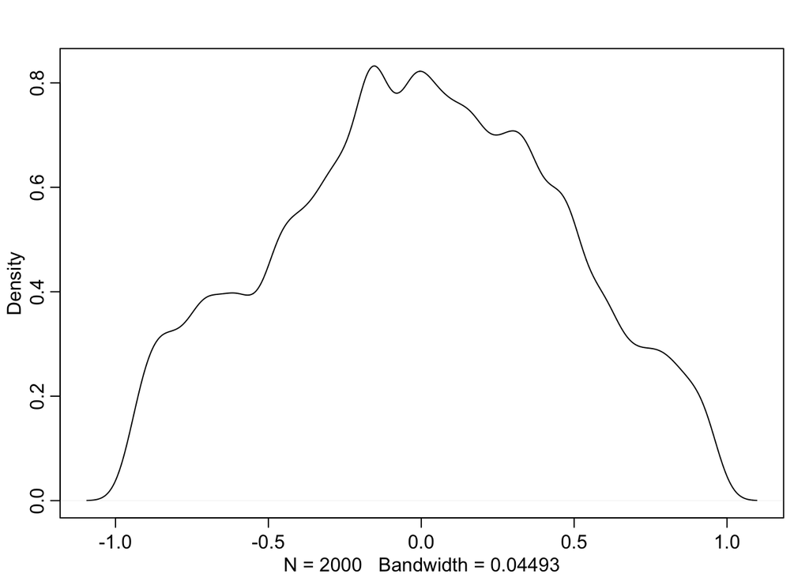

```r
post2 <- extract.samples(m14.M1)

#plotting

dens(post2$Rho[,1,2])
```

The posterior distribution of the correlation would show that changes in the intercepts of the robot’s response time are not related to changes in the slopes, and vice versa. This is a reflection of the underlying simulation where the intercepts and slopes are independent from each other.